# Tutorial CH6 CH7

Ryan Huang

8/15/2019

# 1 CH6: Overfitting

CH6: Overfitting, Regularization, and Information Criteria (Textbook ver.1)

CH7: Ulysses’ Compass (Textbook ver.2)

### 1.0.1 Define uncertainty: Information entropy

**The uncertainty contained in a probability distribution is the average log-probability of an event.**

### 1.0.2 Entropy to accuracy: Divergence

**Divergence: The additional uncertainty induced by using probabilities from one distribution to describe another distribution.**

Math: The average difference in log probability between the target (p) and model (q).

So if we have a pair of candidate distributions, then the candidate that minimizes the divergence will be closest to the target.

As an approximating function q becomes more accurate, divergence will shrink. So if we have a pair of candidate distributions, then the candidate that minimizes the divergence will be closest to the target.

### 1.0.3 Model Comparison: Deviance & log-prob score

`lppd` (log-pointwise-predictive-density): 加總所有observation 在所有sample的平均log-prob score, higher the better deviance = -2 * lppd, lower the better

## 1.1 Out of sample: Predicting predictive accuracy

1. Cross validation
- LOOCV: leave-one-out cross-validation, use n = sample size - 1 as training data and the only one left as testing data
- LOOIS: Pareto-smoothed importance sampling leave-one-out cross-validation, more efficient way of LOOCV
2. Information criteria
- AIC: `-2lppd + 2p`, lower(lower deviance or fewer parameters) the better. *highly constrained*
- WAIC: `lppd + penalty term`, penalty term is defined as “sum of the variance in log-prob for each observation i.” *widely applicable* *pointwise*

```r
library(rethinking)
library(rstan)
library(tidyverse)
library(gridExtra)
```

# 2 CH7: Interaction

CH7: Interactions (Textbook ver.1)

CH8: Conditional Manatees (Textbook ver.2)

## 2.1 Cate. variable * cont. variable

### 2.1.1 Data: rugged(GDP)

- Rescaling:
- gpd: log & mean scaling (average is 1)
- rugged: max scaling (because 0 is important, % of max value)

```r
data("rugged")

# extract countries with GDP data
rugged = rugged %>%
  filter(complete.cases(rgdppc_2000))

# rescale variables
rugged = rugged %>%
  mutate(
    log_gdp = log(rgdppc_2000)) %>%
  mutate(
    log_gdp_std = log_gdp / mean(log_gdp),
    rugged_std = rugged / max(rugged))
```

### 2.1.2 Model

#### 2.1.2.1 Prior

Prior diagnosis: 1. `a` close to the avg. log GDP (`1` because we rescale) 2. most extreme case of `|b|`: max(log_GDP) - min(log_GDP)

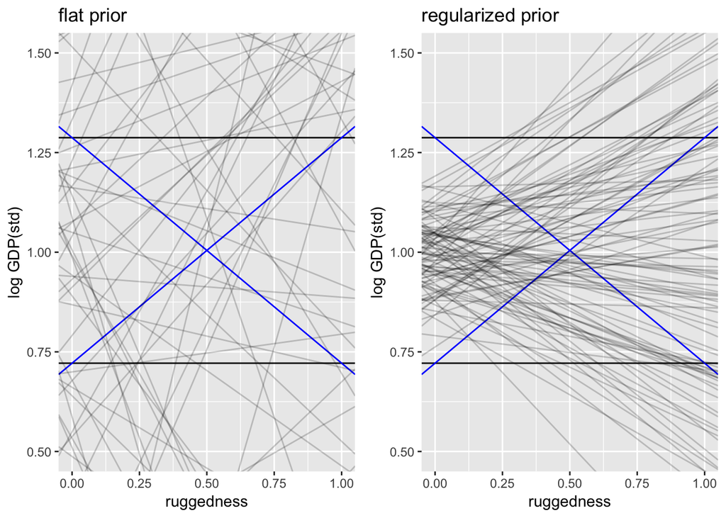

```r
# search of reasonable priors
n = 100
a1 = rnorm(n, 1, 1)
a2 = rnorm(n, 1, .1)

b1 = rnorm(n, 0, 1)
b2 = rnorm(n, 0, .3)

p1 = ggplot() +
  xlim(0, 1) +
  ylim(0.5, 1.5) +
  geom_hline(yintercept = max(rugged$log_gdp_std)) +
  geom_hline(yintercept = min(rugged$log_gdp_std)) +
  geom_abline(intercept = max(rugged$log_gdp_std),
              slope = (min(rugged$log_gdp_std) - max(rugged$log_gdp_std)),
              color="blue") +
  geom_abline(intercept = min(rugged$log_gdp_std),
              slope = (max(rugged$log_gdp_std) - min(rugged$log_gdp_std)),
              color="blue") +
  labs(x="ruggedness", y="log GDP(std)", title="flat prior")
p2 = ggplot() +
  xlim(0, 1) +
  ylim(0.5, 1.5) +
  geom_hline(yintercept = max(rugged$log_gdp_std)) +
  geom_hline(yintercept = min(rugged$log_gdp_std)) +
  geom_abline(intercept = max(rugged$log_gdp_std),
              slope = (min(rugged$log_gdp_std) - max(rugged$log_gdp_std)),
              color="blue") +
  geom_abline(intercept = min(rugged$log_gdp_std),
              slope = (max(rugged$log_gdp_std) - min(rugged$log_gdp_std)),
              color="blue") +
  labs(x="ruggedness", y="log GDP(std)", title="regularized prior")

for (i in 1:n) {
  p1 = p1 + geom_abline(intercept = a1[i], slope = b1[i], alpha=.2)
  p2 = p2 + geom_abline(intercept = a2[i], slope = b2[i], alpha=.2)
}

grid.arrange(p1, p2, nrow=1)
```

#### Model 7.1: basic `GDP ~ a + b * ruggedness`

```r
m7.1 = "
data {
    int N;
    vector[N] loggdp;
    vector[N] rugged;
}
parameters {
    real a;
    real b;
    real sigma;
}
model {
    vector[N] mu = a + b * rugged;
    loggdp ~ normal(mu, sigma);

    a ~ normal(1, 0.1);
    b ~ normal(0, 0.3);
    sigma ~ exponential(1);
}
generated quantities {
    vector[N] pred_mu;
    real pred_y[N];
    vector[N] log_lik; // for model comparison

  pred_mu = a + b * rugged;
    pred_y = normal_rng(pred_mu, sigma);

  for (i in 1:N){
    log_lik[i] = normal_lpdf(loggdp[i] | pred_mu[i], sigma);
  }

}
"
dat7.1 = list(N = nrow(rugged),
              loggdp = rugged$log_gdp_std,
              rugged = rugged$rugged_std - mean(rugged$rugged_std))

fit7.1 = stan(model_code = m7.1,
              data = dat7.1,
              cores = 2,
              chains = 2,
              iter = 2000)
```

```r
print(fit7.1, pars=c("a", "b","sigma"), prob=c(.025, .975))
```

```
## Inference for Stan model: 4d13bb2b67ee015e5affdfab924aa93c.
## 2 chains, each with iter=2000; warmup=1000; thin=1;
## post-warmup draws per chain=1000, total post-warmup draws=2000.
##
##       mean se_mean   sd  2.5% 97.5% n_eff Rhat
## a     1.00       0 0.01  0.98  1.02  2223    1
## b     0.00       0 0.06 -0.10  0.10  1722    1
## sigma 0.14       0 0.01  0.12  0.15  2027    1
##
## Samples were drawn using NUTS(diag_e) at Sat Aug 24 10:54:02 2019.
## For each parameter, n_eff is a crude measure of effective sample size,
## and Rhat is the potential scale reduction factor on split chains (at
## convergence, Rhat=1).
```

#### 2.1.2.2 Model 7.2: different intercept

model_2: GDP ~ a[i] + b * ruggedness, i = 1(africa) or i = 0(non-africa)

```r
m7.2 = "
data {
    int N;
    int L;
    vector[N] loggdp;
    vector[N] rugged;
    int africa[N];
}
parameters {
    real a[L];
    real b;
    real sigma;
}
model {
    vector[N] mu;
    for (i in 1:N){
        mu[i] = a[africa[i]] + b * rugged[i];
    }

    loggdp ~ normal(mu, sigma);

    for (i in 1:L){
        a[i] ~ normal(1, 0.1);
    }

    b ~ normal(0, 0.3);
    sigma ~ exponential(1);
}
generated quantities {
    vector[N] pred_mu;
    real pred_y[N];
    vector[N] log_lik;

    for (i in 1:N){
        pred_mu[i] = a[africa[i]] + b * rugged[i];
        log_lik[i] = normal_lpdf(loggdp[i] | pred_mu[i], sigma);
    }

    pred_y = normal_rng(pred_mu, sigma);

}
"
dat7.2 = list(N = nrow(rugged),
              L = rugged$cont_africa %>% unique() %>% length(),
              rugged = rugged$rugged_std - mean(rugged$rugged_std),
              loggdp = rugged$log_gdp_std,
              africa = rugged$cont_africa+1
)
fit7.2 = stan(model_code = m7.2,
              data = dat7.2,
              cores = 2,
              chains = 2,
              iter = 2000)
```

```r
print(fit7.2, pars=c("a", "b","sigma"), prob=c(.025, .975))
```

```
## Inference for Stan model: 6a585413becca1089f48ba5f380db117.
## 2 chains, each with iter=2000; warmup=1000; thin=1;
## post-warmup draws per chain=1000, total post-warmup draws=2000.
##
##        mean se_mean   sd  2.5% 97.5% n_eff Rhat
## a[1]   1.05       0 0.01  1.03  1.07  2211    1
## a[2]   0.88       0 0.02  0.85  0.91  2049    1
## b     -0.05       0 0.05 -0.14  0.04  1904    1
## sigma  0.11       0 0.01  0.10  0.13  1732    1
##
## Samples were drawn using NUTS(diag_e) at Sat Aug 24 10:55:12 2019.
## For each parameter, n_eff is a crude measure of effective sample size,
## and Rhat is the potential scale reduction factor on split chains (at
## convergence, Rhat=1).
```

#### 2.1.2.3 Model 7.3: different intercept + different slope

model_3: GDP ~ a[i] + b[i] * ruggedness, i = 1(africa) or i = 0(non-africa)

```r
m7.3 = "
data {
    int N;
    int L;
    vector[N] loggdp;
    vector[N] rugged;
    int africa[N];
}
parameters {
    real a[L];
    real b[L];
    real sigma;
}
model {
    vector[N] mu;
    for (i in 1:N){
        mu[i] = a[africa[i]] + b[africa[i]] * rugged[i];
    }

    loggdp ~ normal(mu, sigma);

    for (i in 1:L){
        a[i] ~ normal(1, 0.1);
        b[i] ~ normal(0, 0.3);
    }

    sigma ~ exponential(1);
}
generated quantities {
    vector[N] pred_mu;
    real pred_y[N];
    vector[N] log_lik;

    for (i in 1:N){
        pred_mu[i] = a[africa[i]] + b[africa[i]] * rugged[i];
        log_lik[i] = normal_lpdf(loggdp[i] | pred_mu[i], sigma);
    }

    pred_y = normal_rng(pred_mu, sigma);

}
"
dat7.3 = list(N = nrow(rugged),
              L = rugged$cont_africa %>% unique() %>% length(),
              rugged = rugged$rugged_std - mean(rugged$rugged_std),
              loggdp = rugged$log_gdp_std,
              africa = rugged$cont_africa+1
)
fit7.3 = stan(model_code = m7.3,
              data = dat7.3,
              cores = 2,
              chains = 2,
              iter = 2000)
```

```r
print(fit7.3, pars=c("a", "b","sigma"), prob=c(.025, .975))
```

```
## Inference for Stan model: 39db6c608f7d5b0f4e0bcd36493e99f9.
## 2 chains, each with iter=2000; warmup=1000; thin=1;
## post-warmup draws per chain=1000, total post-warmup draws=2000.
##
##        mean se_mean   sd  2.5% 97.5% n_eff Rhat
## a[1]   1.05       0 0.01  1.03  1.07  2654    1
## a[2]   0.89       0 0.02  0.86  0.92  2653    1
## b[1]  -0.14       0 0.06 -0.25 -0.03  2776    1
## b[2]   0.13       0 0.08 -0.02  0.28  2162    1
## sigma  0.11       0 0.01  0.10  0.12  3373    1
##
## Samples were drawn using NUTS(diag_e) at Sat Aug 24 10:56:17 2019.
## For each parameter, n_eff is a crude measure of effective sample size,
## and Rhat is the potential scale reduction factor on split chains (at
## convergence, Rhat=1).
```

### 2.1.3 Posterior Prediction

#### 2.1.3.1 Model 7.1

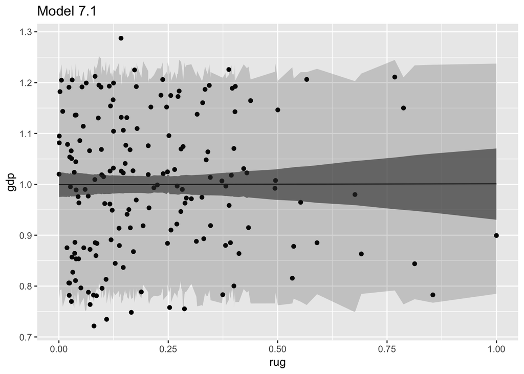

```r
post7.1 = fit7.1 %>% as.data.frame()
pred_mu7.1 = post7.1 %>% select(contains("pred_mu"))
pred_y7.1 = post7.1 %>% select(contains("pred_y"))

result7.1 = data.frame(
  pred_mu = pred_mu7.1 %>% apply(., 2, mean),
  CI_lower = pred_mu7.1 %>% apply(., 2, HPDI) %>% .[1,],
  CI_upper = pred_mu7.1 %>% apply(., 2, HPDI) %>% .[2,],
  PI_lower = pred_y7.1 %>% apply(., 2, HPDI) %>% .[1,],
  PI_upper = pred_y7.1 %>% apply(., 2, HPDI) %>% .[2,],
  gdp = rugged$log_gdp_std,
  rug = rugged$rugged_std,
  africa = rugged$cont_africa
)

result7.1 %>%
  ggplot() +
  geom_point(aes(rug, gdp)) +
  geom_line(aes(rug, pred_mu)) +
  geom_ribbon(aes(x=rug, ymin=CI_lower, ymax=CI_upper), alpha=.6) +
  geom_ribbon(aes(x=rug, ymin=PI_lower, ymax=PI_upper), alpha=.2) +
  ggtitle("Model 7.1")
```

#### Model 7.2

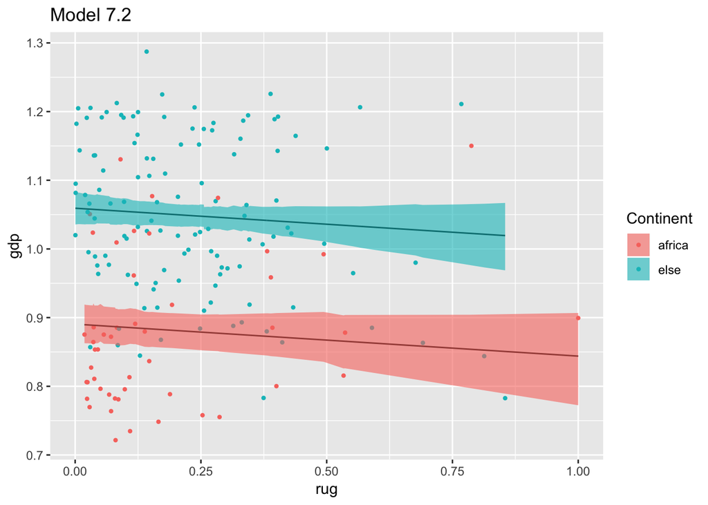

```r
post7.2 = fit7.2 %>% as.data.frame()
pred_mu7.2 = post7.2 %>% select(contains("pred_mu"))
pred_y7.2 = post7.2 %>% select(contains("pred_y"))

result7.2 = data.frame(
  pred_mu = pred_mu7.2 %>% apply(., 2, mean),
  CI_lower = pred_mu7.2 %>% apply(., 2, HPDI) %>% .[1,],
  CI_upper = pred_mu7.2 %>% apply(., 2, HPDI) %>% .[2,],
  PI_lower = pred_y7.2 %>% apply(., 2, HPDI) %>% .[1,],
  PI_upper = pred_y7.2 %>% apply(., 2, HPDI) %>% .[2,],
  gdp = rugged$log_gdp_std,
  rug = rugged$rugged_std,
  africa = rugged$cont_africa
)

p7.2 = result7.2 %>%
  ggplot(aes(fill = ifelse(africa==1, "africa", "else"))) +
  geom_point(aes(rug, gdp), shape=21, stroke=0) + # stroke defines the thickness of the border of the point
  geom_line(aes(rug, pred_mu)) +
  geom_ribbon(aes(x=rug, ymin=CI_lower, ymax=CI_upper), alpha=.6) +
  labs(fill="Continent", title = "Model 7.2")

p7.2
```

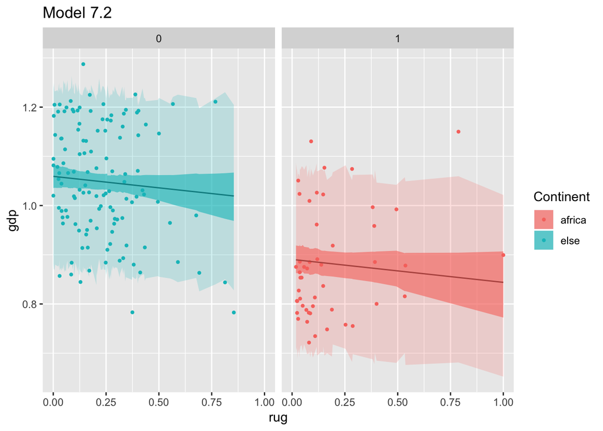

```r
p7.2 +
  facet_wrap(~africa) +
  geom_ribbon(aes(x=rug, ymin=PI_lower, ymax=PI_upper), alpha=.2)
```

#### Model 7.3

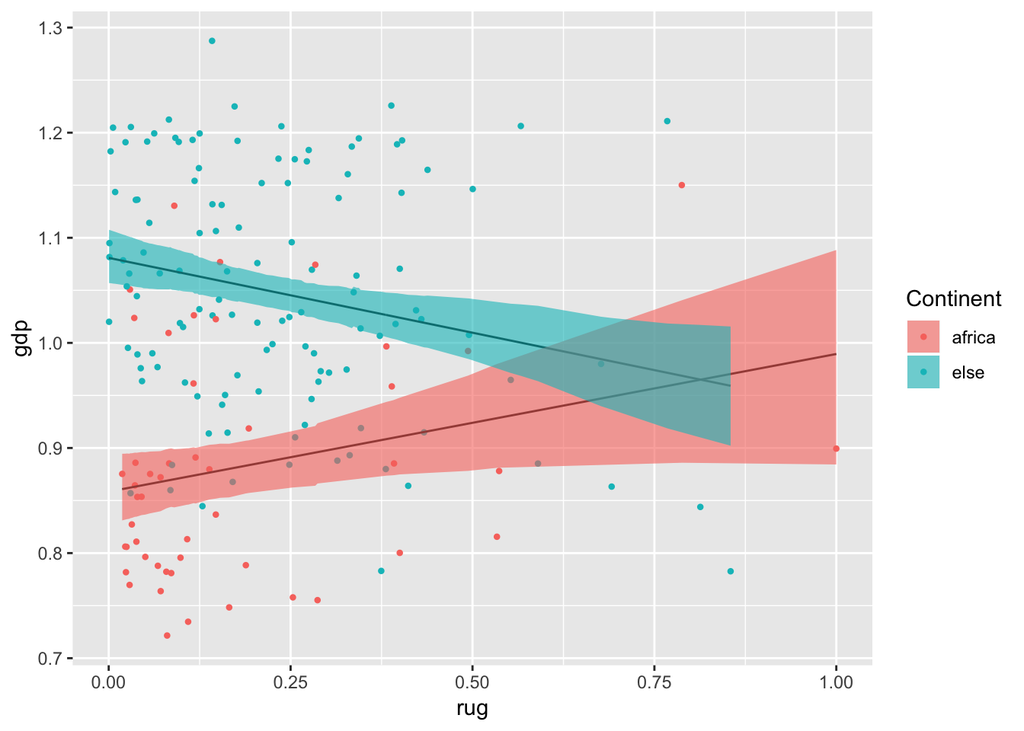

```r
post7.3 = fit7.3 %>% as.data.frame()
pred_mu7.3 = post7.3 %>% select(contains("pred_mu"))
pred_y7.3 = post7.3 %>% select(contains("pred_y"))

result7.3 = data.frame(
  pred_mu = pred_mu7.3 %>% apply(., 2, mean),
  CI_lower = pred_mu7.3 %>% apply(., 2, HPDI) %>% .[1,],
  CI_upper = pred_mu7.3 %>% apply(., 2, HPDI) %>% .[2,],
  PI_lower = pred_y7.3 %>% apply(., 2, HPDI) %>% .[1,],
  PI_upper = pred_y7.3 %>% apply(., 2, HPDI) %>% .[2,],
  gdp = rugged$log_gdp_std,
  rug = rugged$rugged_std,
  africa = rugged$cont_africa
)

p7.3 = result7.3 %>%
  ggplot(aes(rug, gdp, fill = ifelse(africa==1, "africa", "else"))) +
  geom_point(shape=21, stroke=0) + # stroke defines the thickness of the border of the point
  geom_line(aes(rug, pred_mu)) +
  geom_ribbon(aes(x=rug, ymin=CI_lower, ymax=CI_upper), alpha=.6) +
  labs(fill="Continent")

p7.3
```

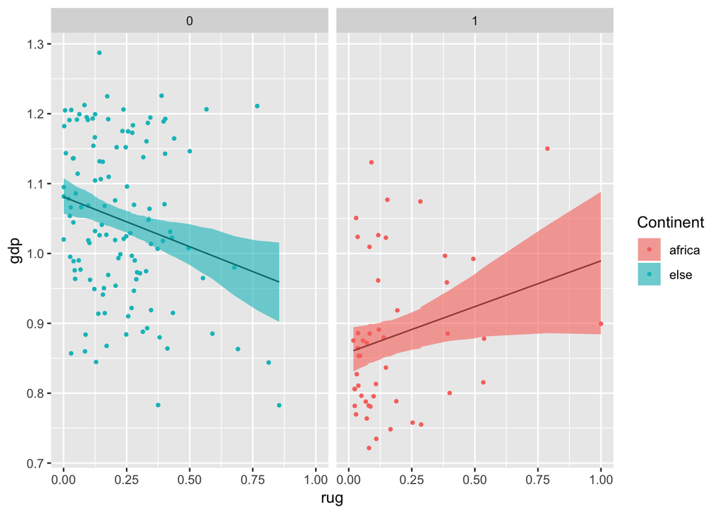

```r
p7.3 + facet_wrap(~africa)
```

### 2.1.4 Model Comparison

```r
rethinking::compare(fit7.1, fit7.2, fit7.3)
```

```
##          WAIC pWAIC dWAIC weight    SE   dSE
## fit7.3 -259.2   5.0   0.0   0.97 14.69    NA
## fit7.2 -252.2   4.2   7.0   0.03 14.83  6.50
## fit7.1 -188.8   2.6  70.3   0.00 12.95 14.96
```

## 2.2 Cont. variable * cont. variable

### 2.2.1 Data: tulips(blooms)

- Rescaling data is to help us to gain some ideas of prior.
- tulip: max scaling(0 is important)
- water / shade: centered ()

```r
data(tulips)
tulips$blooms_std <- tulips$blooms / max(tulips$blooms)
tulips$water_cent <- tulips$water - mean(tulips$water)
tulips$shade_cent <- tulips$shade - mean(tulips$shade)
```

### 2.2.2 Model

Prior diagnosis: 1. a > 0 and a < 1 2. maxium change in `water` and `shade` is 2, maxium change in `blooms_std` is 1. |b| < 0.5

#### 2.2.2.1 Model 7.4: basic

`bloosm ~ a + b1 * water + b2 * shade`

```r
m7.4 = "
data {
    int N;
    vector[N] blooms;
    vector[N] water;
    vector[N] shadow;
}
parameters {
    real a;
    real bw;
    real bs;
    real sigma;
}
model {
    vector[N] mu;
    mu = a + bw * water + bs * shadow;
    blooms ~ normal(mu, sigma);

    a ~ normal( 0.5 , 0.25 );
    bw ~ normal( 0 , 0.25 );
    bs ~ normal( 0 , 0.25 );
    sigma ~ exponential( 1 );
}
generated quantities {
    vector[N] pred_mu;
    real pred_y[N];
    vector[N] log_lik;

    pred_mu = a + bw * water + bs * shadow;

    for (i in 1:N){
        log_lik[i] = normal_lpdf(blooms[i] | pred_mu[i], sigma);
    }

    pred_y = normal_rng(pred_mu, sigma);
}
"
dat7.4 = list(N = nrow(tulips),
              blooms = tulips$blooms_std,
              water = tulips$water_cent,
              shadow = tulips$shade_cent
)
fit7.4 = stan(model_code = m7.4,
              data = dat7.4,
              cores = 2,
              chains = 2,
              iter = 2000)
```

```r
print(fit7.4, pars=c("a", "bw", "bs","sigma"), prob=c(.025, .975))
```

```
## Inference for Stan model: 44b0bebe3340f6c2fbcec39f94f82fd2.
## 2 chains, each with iter=2000; warmup=1000; thin=1;
## post-warmup draws per chain=1000, total post-warmup draws=2000.
##
##        mean se_mean   sd  2.5% 97.5% n_eff Rhat
## a      0.36       0 0.03  0.29  0.43  1993    1
## bw     0.20       0 0.04  0.12  0.29  1714    1
## bs    -0.11       0 0.04 -0.20 -0.03  1966    1
## sigma  0.18       0 0.03  0.13  0.24  1018    1
##
## Samples were drawn using NUTS(diag_e) at Sat Aug 24 10:57:26 2019.
## For each parameter, n_eff is a crude measure of effective sample size,
## and Rhat is the potential scale reduction factor on split chains (at
## convergence, Rhat=1).
```

#### 2.2.2.2 Model 7.5: interaction

`bloosm ~ a + b1 * water + b2 * shade + b3 * water * shade`

Prior of b3: assume the strongest interaction is high enough to make other var. have zero effect. So b3 should be the same magnitude as the main effect.

```r
m7.5 = "
data {
    int N;
    vector[N] blooms;
    vector[N] water;
    vector[N] shadow;
}
parameters {
    real a;
    real bw;
    real bs;
    real bws;
    real sigma;
}
model {
    vector[N] mu;
    mu = a + bw * water + bs * shadow + bws * water .* shadow;
  blooms ~ normal(mu, sigma);

  a ~ normal( 0.5 , 0.25 );
  bw ~ normal( 0 , 0.25 );
  bs ~ normal( 0 , 0.25 );
  bws ~ normal( 0 , 0.25 );
  sigma ~ exponential( 1 );
}
generated quantities {
    vector[N] pred_mu;
    real pred_y[N];
    vector[N] log_lik;

    pred_mu = a + bw * water + bs * shadow + bws * water .* shadow;

    for (i in 1:N){
        log_lik[i] = normal_lpdf(blooms[i] | pred_mu[i], sigma);
    }

    pred_y = normal_rng(pred_mu, sigma);
}
"
dat7.5 = list(N = nrow(tulips),
              blooms = tulips$blooms_std,
              water = tulips$water_cent,
              shadow = tulips$shade_cent
)
fit7.5 = stan(model_code = m7.5,
              data = dat7.5,
              cores = 2,
              chains = 2,
              iter = 2000)
```

```r
print(fit7.5, pars=c("a", "bw", "bs","bws","sigma"), prob=c(.025, .975))
```

```
## Inference for Stan model: 0d4e34649c93cb92a5492a919b6ca6c9.
## 2 chains, each with iter=2000; warmup=1000; thin=1;
## post-warmup draws per chain=1000, total post-warmup draws=2000.
##
##        mean se_mean   sd  2.5% 97.5% n_eff Rhat
## a      0.36       0 0.03  0.30  0.41  2462    1
## bw     0.21       0 0.03  0.14  0.28  2469    1
## bs    -0.11       0 0.03 -0.18 -0.05  2604    1
## bws   -0.14       0 0.04 -0.22 -0.06  2635    1
## sigma  0.14       0 0.02  0.11  0.20  1314    1
##
## Samples were drawn using NUTS(diag_e) at Sat Aug 24 10:58:33 2019.
## For each parameter, n_eff is a crude measure of effective sample size,
## and Rhat is the potential scale reduction factor on split chains (at
## convergence, Rhat=1).
```

### 2.2.3 Posterior Prediction

#### 2.2.3.1 Model 7.4

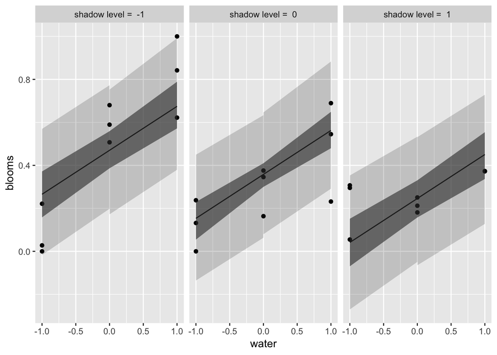

```r
pred_mu7.4 = fit7.4 %>% as.data.frame() %>% select(contains("pred_mu"))
pred_y7.4 = fit7.4 %>% as.data.frame() %>% select(contains("pred_y"))

result7.4 = data.frame(
  pred_mu = pred_mu7.4 %>% apply(., 2, mean),
  CI_lower = pred_mu7.4 %>% apply(., 2, HPDI) %>% .[1,],
  CI_upper = pred_mu7.4 %>% apply(., 2, HPDI) %>% .[2,],
  PI_lower = pred_y7.4 %>% apply(., 2, HPDI) %>% .[1,],
  PI_upper = pred_y7.4 %>% apply(., 2, HPDI) %>% .[2,],
  water = tulips$water_cent,
  shadow = tulips$shade_cent,
  blooms = tulips$blooms_std,
  water_level = paste("water level = ",tulips$water_cent),
  shadow_level = paste("shadow level = ",tulips$shade_cent)
)

result7.4 %>%
  ggplot() +
  geom_point(aes(water,blooms)) +
  geom_line(aes(water, pred_mu)) +
  geom_ribbon(aes(x=water, ymin=CI_lower, ymax=CI_upper), alpha=.6) +
  geom_ribbon(aes(x=water, ymin=PI_lower, ymax=PI_upper), alpha=.2) +
  facet_grid(~shadow_level)
```

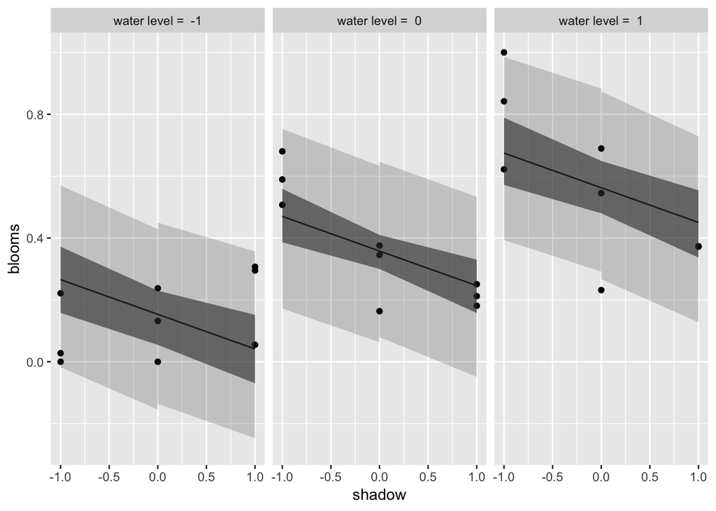

```r
result7.4 %>%
  ggplot() +
  geom_point(aes(shadow,blooms)) +
  geom_line(aes(shadow, pred_mu)) +
  geom_ribbon(aes(x=shadow, ymin=CI_lower, ymax=CI_upper), alpha=.6) +
  geom_ribbon(aes(x=shadow, ymin=PI_lower, ymax=PI_upper), alpha=.2) +
  facet_wrap(~water_level)
```

#### 2.2.3.2 Model 7.5

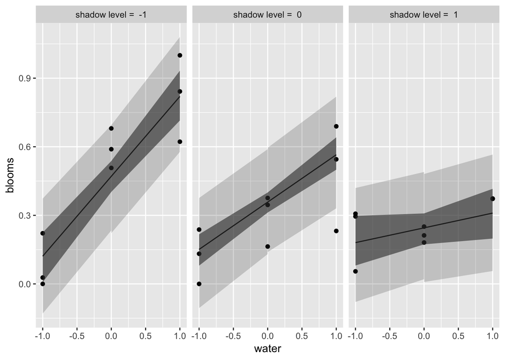

```r
pred_mu7.5 = fit7.5 %>% as.data.frame() %>% select(contains("pred_mu"))
pred_y7.5 = fit7.5 %>% as.data.frame() %>% select(contains("pred_y"))

result7.5 = data.frame(
  pred_mu = pred_mu7.5 %>% apply(., 2, mean),
  CI_lower = pred_mu7.5 %>% apply(., 2, HPDI) %>% .[1,],
  CI_upper = pred_mu7.5 %>% apply(., 2, HPDI) %>% .[2,],
  PI_lower = pred_y7.5 %>% apply(., 2, HPDI) %>% .[1,],
  PI_upper = pred_y7.5 %>% apply(., 2, HPDI) %>% .[2,],
  water = tulips$water_cent,
  shadow = tulips$shade_cent,
  blooms = tulips$blooms_std,
  water_level = paste("water level = ",tulips$water_cent),
  shadow_level = paste("shadow level = ",tulips$shade_cent)
)

result7.5 %>%
  ggplot() +
  geom_point(aes(water,blooms)) +
  geom_line(aes(water, pred_mu)) +
  geom_ribbon(aes(x=water, ymin=CI_lower, ymax=CI_upper), alpha=.6) +
  geom_ribbon(aes(x=water, ymin=PI_lower, ymax=PI_upper), alpha=.2) +
  facet_grid(~shadow_level)
```

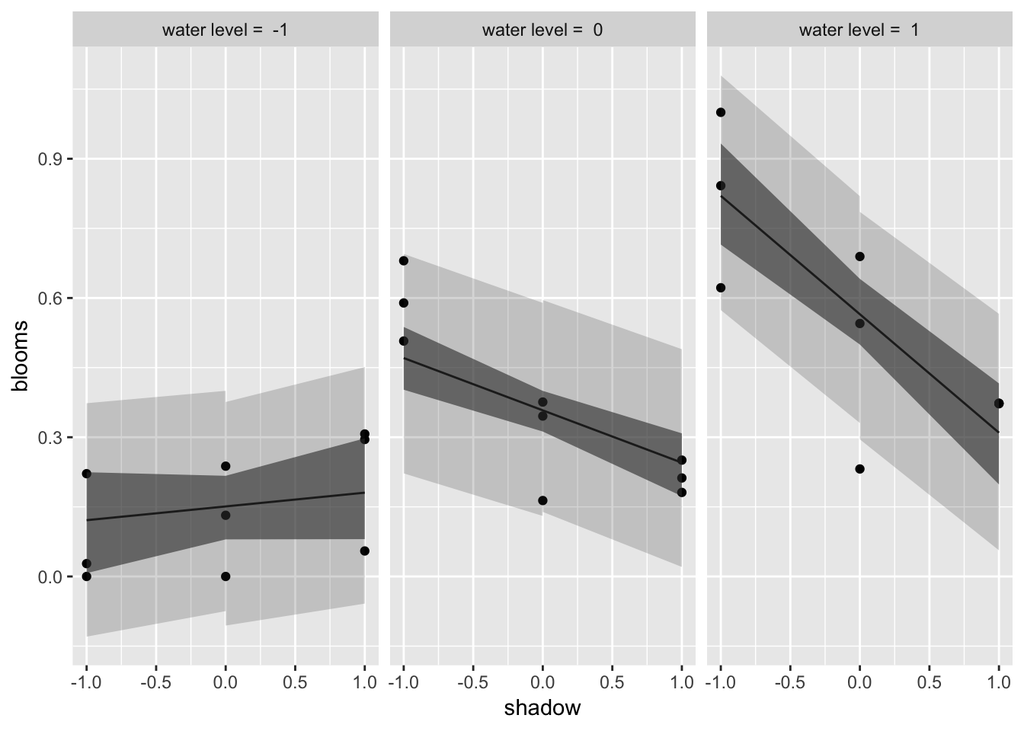

```r
result7.5 %>%
  ggplot() +
  geom_point(aes(shadow,blooms)) +
  geom_line(aes(shadow, pred_mu)) +
  geom_ribbon(aes(x=shadow, ymin=CI_lower, ymax=CI_upper), alpha=.6) +
  geom_ribbon(aes(x=shadow, ymin=PI_lower, ymax=PI_upper), alpha=.2) +
  facet_wrap(~water_level)
```

### 2.2.4 Model Comparison

```r
library(loo)
fit7.4 %>% extract_log_lik() %>% waic()
```

```
##
## Computed from 2000 by 27 log-likelihood matrix
##
##           Estimate  SE
## elpd_waic      7.0 3.5
## p_waic         3.9 1.0
## waic         -13.9 7.1
```

```r
fit7.5 %>% extract_log_lik() %>% waic()
```

```
##
## Computed from 2000 by 27 log-likelihood matrix
##
##           Estimate  SE
## elpd_waic     12.5 3.7
## p_waic         4.3 1.1
## waic         -25.0 7.5
```

```r
rethinking::compare(fit7.4, fit7.5)
```

```
##         WAIC pWAIC dWAIC weight   SE  dSE
## fit7.5 -25.0   4.3   0.0      1 7.35   NA
## fit7.4 -13.9   3.9  11.1      0 6.93 5.97
```

### 2.2.5 Explaination

Tulips need both water and light to produce blooms. At low light levels, water can’t have much of an effect, because the tulips don’t have enough light to produce blooms. At higher light levels, water can matter more, because the tulips have enough light to produce blooms. At very high light levels, light is no longer limiting the blooms, and so water can have a much more dramatic impact on the outcome.